# PCA + Feature Selection

Ruth Muriithi

1/23/2021

#Specifying the Question

*Undertaking a project on behalf of Carrefour Kenya, that will inform the marketing department on the most relevant marketing strategies that will result in the highest no. of sales.*

#Defining the metric for success

The ability adequately selecting our features and reduce our dimensions is what will determine whether the project is a success or not.

#Understanding the context

Carrefour is a multinational corporation of French origin specialized in retail. I was founded in 1958, making it 62 years old.

In 2016 Carrefour set up shop in Kenya, It is currently in 15 countries and has over 250 hypermarkets.

This project is being done on behalf of Carrefour Kenya, I will be undertaking a project that will inform the marketing department on the most relevant marketing strategies that will result in the highest no. of sales (total price including tax).

#Recording the experimental design The findings of my analysis will be recorded in this markdown file and uploaded on github.

#Data reading and checking

```r
df <- read.csv("http://bit.ly/CarreFourDataset")
head(df)
```

```
##    Invoice.ID Branch Customer.type Gender           Product.line Unit.price
## 1 750-67-8428      A        Member Female      Health and beauty      74.69
## 2 226-31-3081      C        Normal Female Electronic accessories      15.28
## 3 631-41-3108      A        Normal   Male     Home and lifestyle      46.33
## 4 123-19-1176      A        Member   Male      Health and beauty      58.22
## 5 373-73-7910      A        Normal   Male      Sports and travel      86.31
## 6 699-14-3026      C        Normal   Male Electronic accessories      85.39
##   Quantity     Tax      Date  Time     Payment   cogs gross.margin.percentage
## 1        7 26.1415  1/5/2019 13:08     Ewallet 522.83                4.761905
## 2        5  3.8200  3/8/2019 10:29        Cash  76.40                4.761905
## 3        7 16.2155  3/3/2019 13:23 Credit card 324.31                4.761905
## 4        8 23.2880 1/27/2019 20:33     Ewallet 465.76                4.761905
## 5        7 30.2085  2/8/2019 10:37     Ewallet 604.17                4.761905
## 6        7 29.8865 3/25/2019 18:30     Ewallet 597.73                4.761905
##   gross.income Rating    Total
## 1      26.1415    9.1 548.9715
## 2       3.8200    9.6  80.2200
## 3      16.2155    7.4 340.5255
## 4      23.2880    8.4 489.0480
## 5      30.2085    5.3 634.3785
## 6      29.8865    4.1 627.6165
```

```r
summary(df)
```

```
##   Invoice.ID           Branch          Customer.type         Gender
##  Length:1000        Length:1000        Length:1000        Length:1000
##  Class :character   Class :character   Class :character   Class :character
##  Mode  :character   Mode  :character   Mode  :character   Mode  :character
##
##
##
##  Product.line         Unit.price       Quantity          Tax
##  Length:1000        Min.   :10.08   Min.   : 1.00   Min.   : 0.5085
##  Class :character   1st Qu.:32.88   1st Qu.: 3.00   1st Qu.: 5.9249
##  Mode  :character   Median :55.23   Median : 5.00   Median :12.0880
##                     Mean   :55.67   Mean   : 5.51   Mean   :15.3794
##                     3rd Qu.:77.94   3rd Qu.: 8.00   3rd Qu.:22.4453
##                     Max.   :99.96   Max.   :10.00   Max.   :49.6500
##      Date               Time             Payment               cogs
##  Length:1000        Length:1000        Length:1000        Min.   : 10.17
##  Class :character   Class :character   Class :character   1st Qu.:118.50
##  Mode  :character   Mode  :character   Mode  :character   Median :241.76
##                                                           Mean   :307.59
##                                                           3rd Qu.:448.90
##                                                           Max.   :993.00
##  gross.margin.percentage  gross.income         Rating           Total
##  Min.   :4.762           Min.   : 0.5085   Min.   : 4.000   Min.   :  10.68
##  1st Qu.:4.762           1st Qu.: 5.9249   1st Qu.: 5.500   1st Qu.: 124.42
##  Median :4.762           Median :12.0880   Median : 7.000   Median : 253.85
##  Mean   :4.762           Mean   :15.3794   Mean   : 6.973   Mean   : 322.97
##  3rd Qu.:4.762           3rd Qu.:22.4453   3rd Qu.: 8.500   3rd Qu.: 471.35
##  Max.   :4.762           Max.   :49.6500   Max.   :10.000   Max.   :1042.65
```

```r
#Checking the data type of each column
#

str(df)
```

```
## 'data.frame':    1000 obs. of  16 variables:
##  $ Invoice.ID             : chr  "750-67-8428" "226-31-3081" "631-41-3108" "123-19-1176" ...
##  $ Branch                 : chr  "A" "C" "A" "A" ...
##  $ Customer.type          : chr  "Member" "Normal" "Normal" "Member" ...
##  $ Gender                 : chr  "Female" "Female" "Male" "Male" ...
##  $ Product.line           : chr  "Health and beauty" "Electronic accessories" "Home and lifestyle" "Health and beauty" ...
##  $ Unit.price             : num  74.7 15.3 46.3 58.2 86.3 ...
##  $ Quantity               : int  7 5 7 8 7 7 6 10 2 3 ...
##  $ Tax                    : num  26.14 3.82 16.22 23.29 30.21 ...
##  $ Date                   : chr  "1/5/2019" "3/8/2019" "3/3/2019" "1/27/2019" ...
##  $ Time                   : chr  "13:08" "10:29" "13:23" "20:33" ...
##  $ Payment                : chr  "Ewallet" "Cash" "Credit card" "Ewallet" ...
##  $ cogs                   : num  522.8 76.4 324.3 465.8 604.2 ...
##  $ gross.margin.percentage: num  4.76 4.76 4.76 4.76 4.76 ...
##  $ gross.income           : num  26.14 3.82 16.22 23.29 30.21 ...
##  $ Rating                 : num  9.1 9.6 7.4 8.4 5.3 4.1 5.8 8 7.2 5.9 ...
##  $ Total                  : num  549 80.2 340.5 489 634.4 ...
```

*Data Cleaning*

```r
#Preview the column names
#
df.copy <- df
colnames(df)
```

```
##  [1] "Invoice.ID"              "Branch"
##  [3] "Customer.type"           "Gender"
##  [5] "Product.line"            "Unit.price"
##  [7] "Quantity"                "Tax"
##  [9] "Date"                    "Time"
## [11] "Payment"                 "cogs"
## [13] "gross.margin.percentage" "gross.income"
## [15] "Rating"                  "Total"
```

```r
#shape of the dataset
#

dim(df)
```

```
## [1] 1000   16
```

```r
# Tidying the Data

#Checking for duplicates
#

anyDuplicated(df)
```

```
## [1] 0
```

There are no duplicates in our dataset.

```r
#Checking for missing values
#

colSums(is.na(df))
```

```
##              Invoice.ID                  Branch           Customer.type
##                       0                       0                       0
##                  Gender            Product.line              Unit.price
##                       0                       0                       0
##                Quantity                     Tax                    Date
##                       0                       0                       0
##                    Time                 Payment                    cogs
##                       0                       0                       0
## gross.margin.percentage            gross.income                  Rating
##                       0                       0                       0
##                   Total
##                       0
```

None of the columns have a missing value.

We’ll factorise our character

```r
## Encoding
df$Branch <- as.factor(df$Branch)
df$Product.line <- as.factor(df$Product.line)
df$Payment <- as.factor(df$Payment)
df$Customer.type <- as.factor(df$Customer.type)
df$Gender <- as.factor(df$Gender)

str(df)
```

```
## 'data.frame':    1000 obs. of  16 variables:
##  $ Invoice.ID             : chr  "750-67-8428" "226-31-3081" "631-41-3108" "123-19-1176" ...
##  $ Branch                 : Factor w/ 3 levels "A","B","C": 1 3 1 1 1 3 1 3 1 2 ...
##  $ Customer.type          : Factor w/ 2 levels "Member","Normal": 1 2 2 1 2 2 1 2 1 1 ...
##  $ Gender                 : Factor w/ 2 levels "Female","Male": 1 1 2 2 2 2 1 1 1 1 ...
##  $ Product.line           : Factor w/ 6 levels "Electronic accessories",..: 4 1 5 4 6 1 1 5 4 3 ...
##  $ Unit.price             : num  74.7 15.3 46.3 58.2 86.3 ...
##  $ Quantity               : int  7 5 7 8 7 7 6 10 2 3 ...
##  $ Tax                    : num  26.14 3.82 16.22 23.29 30.21 ...
##  $ Date                   : chr  "1/5/2019" "3/8/2019" "3/3/2019" "1/27/2019" ...
##  $ Time                   : chr  "13:08" "10:29" "13:23" "20:33" ...
##  $ Payment                : Factor w/ 3 levels "Cash","Credit card",..: 3 1 2 3 3 3 3 3 2 2 ...
##  $ cogs                   : num  522.8 76.4 324.3 465.8 604.2 ...
##  $ gross.margin.percentage: num  4.76 4.76 4.76 4.76 4.76 ...
##  $ gross.income           : num  26.14 3.82 16.22 23.29 30.21 ...
##  $ Rating                 : num  9.1 9.6 7.4 8.4 5.3 4.1 5.8 8 7.2 5.9 ...
##  $ Total                  : num  549 80.2 340.5 489 634.4 ...
```

```r
#Label Encoding
#Customer_type
#
df$Customer.type <- ifelse(df$Customer.type == "Member",1,0)
df$Gender <- ifelse(df$Gender == "Female",1,0)

table(df$Customer.type)
```

```
##
##   0   1
## 499 501
```

```r
table(df$Gender)
```

```
##
##   0   1
## 499 501
```

```r
head(df)
```

```
##    Invoice.ID Branch Customer.type Gender           Product.line Unit.price
## 1 750-67-8428      A             1      1      Health and beauty      74.69
## 2 226-31-3081      C             0      1 Electronic accessories      15.28
## 3 631-41-3108      A             0      0     Home and lifestyle      46.33
## 4 123-19-1176      A             1      0      Health and beauty      58.22
## 5 373-73-7910      A             0      0      Sports and travel      86.31
## 6 699-14-3026      C             0      0 Electronic accessories      85.39
##   Quantity     Tax      Date  Time     Payment   cogs gross.margin.percentage
## 1        7 26.1415  1/5/2019 13:08     Ewallet 522.83                4.761905
## 2        5  3.8200  3/8/2019 10:29        Cash  76.40                4.761905
## 3        7 16.2155  3/3/2019 13:23 Credit card 324.31                4.761905
## 4        8 23.2880 1/27/2019 20:33     Ewallet 465.76                4.761905
## 5        7 30.2085  2/8/2019 10:37     Ewallet 604.17                4.761905
## 6        7 29.8865 3/25/2019 18:30     Ewallet 597.73                4.761905
##   gross.income Rating    Total
## 1      26.1415    9.1 548.9715
## 2       3.8200    9.6  80.2200
## 3      16.2155    7.4 340.5255
## 4      23.2880    8.4 489.0480
## 5      30.2085    5.3 634.3785
## 6      29.8865    4.1 627.6165
```

```r
#install.packages("caret")
library(caret)
require(caret)
df <- df[-c(1,9,10)]
dmy <- dummyVars(" ~ .", data = df, fullRank = T)
df.final <- data.frame(predict(dmy, newdata = df))
df.final
```

[output not shown]

[output cut: 4990 more lines]

# Exploratory Analysis

## Univariate Analysis

```r
#Summary statistics of our dataset

summary(df.copy)
```

```
##   Invoice.ID           Branch          Customer.type         Gender
##  Length:1000        Length:1000        Length:1000        Length:1000
##  Class :character   Class :character   Class :character   Class :character
##  Mode  :character   Mode  :character   Mode  :character   Mode  :character
##
##
##
##  Product.line         Unit.price       Quantity          Tax
##  Length:1000        Min.   :10.08   Min.   : 1.00   Min.   : 0.5085
##  Class :character   1st Qu.:32.88   1st Qu.: 3.00   1st Qu.: 5.9249
##  Mode  :character   Median :55.23   Median : 5.00   Median :12.0880
##                     Mean   :55.67   Mean   : 5.51   Mean   :15.3794
##                     3rd Qu.:77.94   3rd Qu.: 8.00   3rd Qu.:22.4453
##                     Max.   :99.96   Max.   :10.00   Max.   :49.6500
##      Date               Time             Payment               cogs
##  Length:1000        Length:1000        Length:1000        Min.   : 10.17
##  Class :character   Class :character   Class :character   1st Qu.:118.50
##  Mode  :character   Mode  :character   Mode  :character   Median :241.76
##                                                           Mean   :307.59
##                                                           3rd Qu.:448.90
##                                                           Max.   :993.00
##  gross.margin.percentage  gross.income         Rating           Total
##  Min.   :4.762           Min.   : 0.5085   Min.   : 4.000   Min.   :  10.68
##  1st Qu.:4.762           1st Qu.: 5.9249   1st Qu.: 5.500   1st Qu.: 124.42
##  Median :4.762           Median :12.0880   Median : 7.000   Median : 253.85
##  Mean   :4.762           Mean   :15.3794   Mean   : 6.973   Mean   : 322.97
##  3rd Qu.:4.762           3rd Qu.:22.4453   3rd Qu.: 8.500   3rd Qu.: 471.35
##  Max.   :4.762           Max.   :49.6500   Max.   :10.000   Max.   :1042.65
```

## Bivariate Analysis

```r
# Create correlation matrix of data
df.num <- Filter(is.numeric, df.copy)
df.num <- df.num[,c(1:4, 6, 7,8)]
res <- cor(df.num)
round(res, 4)
```

```
##              Unit.price Quantity     Tax    cogs gross.income  Rating   Total
## Unit.price       1.0000   0.0108  0.6340  0.6340       0.6340 -0.0088  0.6340
## Quantity         0.0108   1.0000  0.7055  0.7055       0.7055 -0.0158  0.7055
## Tax              0.6340   0.7055  1.0000  1.0000       1.0000 -0.0364  1.0000
## cogs             0.6340   0.7055  1.0000  1.0000       1.0000 -0.0364  1.0000
## gross.income     0.6340   0.7055  1.0000  1.0000       1.0000 -0.0364  1.0000
## Rating          -0.0088  -0.0158 -0.0364 -0.0364      -0.0364  1.0000 -0.0364
## Total            0.6340   0.7055  1.0000  1.0000       1.0000 -0.0364  1.0000
```

We dropped the gross margin percentage column because it has a standard deviation of zero.

# Multivariate Analysis

```r
head(df.final)
```

```
##   Branch.B Branch.C Customer.type Gender Product.line.Fashion.accessories
## 1        0        0             1      1                                0
## 2        0        1             0      1                                0
## 3        0        0             0      0                                0
## 4        0        0             1      0                                0
## 5        0        0             0      0                                0
## 6        0        1             0      0                                0
##   Product.line.Food.and.beverages Product.line.Health.and.beauty
## 1                               0                              1
## 2                               0                              0
## 3                               0                              0
## 4                               0                              1
## 5                               0                              0
## 6                               0                              0
##   Product.line.Home.and.lifestyle Product.line.Sports.and.travel Unit.price
```

[output cut: 20 more lines]

### PCA

```r
#Dropping the gross_margin_percentage
df.final <- df.final[c(1:15, 17,18,19)]
df.pr <- prcomp(df.final, center = TRUE, scale = TRUE)
summary(df.pr)
```

```
## Importance of components:
##                           PC1     PC2     PC3     PC4     PC5     PC6     PC7
## Standard deviation     2.2204 1.24381 1.23462 1.11188 1.10194 1.08920 1.08524
## Proportion of Variance 0.2739 0.08595 0.08468 0.06868 0.06746 0.06591 0.06543
## Cumulative Proportion  0.2739 0.35985 0.44453 0.51322 0.58067 0.64658 0.71201
##                            PC8     PC9    PC10    PC11   PC12    PC13    PC14
## Standard deviation     1.01639 1.00054 0.97965 0.94343 0.7213 0.69927 0.44855
## Proportion of Variance 0.05739 0.05562 0.05332 0.04945 0.0289 0.02717 0.01118
## Cumulative Proportion  0.76940 0.82502 0.87834 0.92779 0.9567 0.98386 0.99503
##                           PC15      PC16      PC17      PC18
## Standard deviation     0.29897 2.884e-16 1.545e-16 1.499e-17
## Proportion of Variance 0.00497 0.000e+00 0.000e+00 0.000e+00
## Cumulative Proportion  1.00000 1.000e+00 1.000e+00 1.000e+00
```

[figure not shown]

```r
screeplot(df.pr, type = "l", npcs = 15, main = "Screeplot of the first 10 PCs")
abline(h = 1, col="red", lty=5)
legend("topright", legend=c("Eigenvalue = 1"),
       col=c("red"), lty=5, cex=0.6)
```

[figure not shown]

```r
cumpro <- cumsum(df.pr$sdev^2 / sum(df.pr$sdev^2))
plot(cumpro[0:15], xlab = "PC #", ylab = "Amount of explained variance", main = "Cumulative variance plot")
abline(v = 6, col="blue", lty=5)
abline(h = 0.88759, col="blue", lty=5)
legend("topleft", legend=c("Cut-off @ PC6"),
       col=c("blue"), lty=5, cex=0.6)
```

#Claculating the Eigenvalue per component #It is advised to only keep components with an eigenvalue greater than 1

```r
df.pr$sdev ^ 2
```

```
##  [1] 4.930246e+00 1.547072e+00 1.524285e+00 1.236271e+00 1.214266e+00
##  [6] 1.186351e+00 1.177745e+00 1.033054e+00 1.001090e+00 9.597152e-01
## [11] 8.900652e-01 5.202870e-01 4.889756e-01 2.011963e-01 8.938102e-02
## [16] 8.315322e-32 2.387307e-32 2.247864e-34
```

The first 9 variables have a eigenvalue greater than 1, We shall use them for our modelling.

```r
print(df.pr$rotation)
```

```
##                                            PC1          PC2          PC3
## Branch.B                          0.0073319014 -0.530644600 -0.393292238
## Branch.C                         -0.0224131676  0.562112964  0.362368373
## Customer.type                    -0.0126573904  0.114591714 -0.124493507
## Gender                           -0.0280723079  0.147070667 -0.057276855
## Product.line.Fashion.accessories  0.0203286436  0.029347162  0.068984648
## Product.line.Food.and.beverages  -0.0000243418  0.245347437 -0.004676767
## Product.line.Health.and.beauty   -0.0002390852 -0.023732420 -0.006247921
## Product.line.Home.and.lifestyle  -0.0133425316 -0.138323542  0.097346725
## Product.line.Sports.and.travel   -0.0099768799 -0.116145909 -0.163022586
## Unit.price                       -0.2908105956 -0.026360691  0.036939862
## Quantity                         -0.3246544349  0.002749061 -0.025847763
## Tax                              -0.4492892979 -0.006476878 -0.001906097
## Payment.Credit.card              -0.0003911877  0.337006950 -0.580850511
## Payment.Ewallet                   0.0066859818 -0.371887037  0.558297020
## cogs                             -0.4492892979 -0.006476878 -0.001906097
## gross.income                     -0.4492892979 -0.006476878 -0.001906097
## Rating                            0.0185769584  0.143865435  0.056819861
## Total                            -0.4492892979 -0.006476878 -0.001906097
##                                           PC4          PC5          PC6
## Branch.B                         -0.072833091 -0.040742964  0.020523906
## Branch.C                         -0.009794730 -0.017975388  0.004485744
## Customer.type                     0.053003484  0.185305429 -0.037855028
## Gender                           -0.152034863  0.273899909 -0.053538714
## Product.line.Fashion.accessories -0.800742144 -0.160986855 -0.236223672
## Product.line.Food.and.beverages   0.220085074  0.223752961  0.318267778
## Product.line.Health.and.beauty    0.326303064 -0.752323059  0.085938296
## Product.line.Home.and.lifestyle   0.336168024  0.310593465 -0.700150945
## Product.line.Sports.and.travel   -0.061217387  0.363063033  0.528020839
## Unit.price                       -0.178720234 -0.040800196  0.071973259
## Quantity                          0.149789150  0.022198124 -0.048979500
## Tax                              -0.007893441 -0.009662788 -0.000360427
## Payment.Credit.card               0.005421321 -0.072563843 -0.156262307
## Payment.Ewallet                   0.006909788  0.054579995  0.124978807
## cogs                             -0.007893441 -0.009662788 -0.000360427
## gross.income                     -0.007893441 -0.009662788 -0.000360427
## Rating                           -0.033402729 -0.087332983  0.118925332
## Total                            -0.007893441 -0.009662788 -0.000360427
##                                            PC7          PC8           PC9
## Branch.B                         -0.2183585789 -0.094853958  0.0039418016
```

[output cut: 59 more lines]

```
## Gender                           -8.734720e-17 -3.581888e-17 -1.406520e-17
## Product.line.Fashion.accessories -1.202291e-17  2.458133e-18  7.109506e-17
## Product.line.Food.and.beverages  -2.199821e-17  1.129502e-17 -7.907772e-17
## Product.line.Health.and.beauty   -2.527274e-17  1.707487e-17  1.314738e-17
## Product.line.Home.and.lifestyle  -2.362214e-16  3.169820e-17  7.482661e-17
## Product.line.Sports.and.travel    1.053127e-16 -1.268747e-17 -8.579038e-17
## Unit.price                       -1.064255e-16 -9.686411e-17  2.763516e-18
## Quantity                         -4.334847e-16 -1.500104e-16 -5.500324e-19
## Tax                              -2.248513e-01 -4.557623e-01  7.012293e-01
## Payment.Credit.card              -2.284811e-17  1.473679e-17  1.774221e-17
## Payment.Ewallet                   2.371345e-17  1.187972e-17 -7.353544e-18
## cogs                             -3.720771e-01  7.813662e-01  3.202274e-02
## gross.income                     -2.640475e-01 -4.165130e-01 -7.118960e-01
## Rating                            9.174366e-17  4.952725e-17 -9.221899e-17
## Total                             8.609759e-01  9.090908e-02 -2.135610e-02
```

#A biplot, it will help us see the grouping of different variables

```r
library(tidyselect)
library(tidyverse)
```

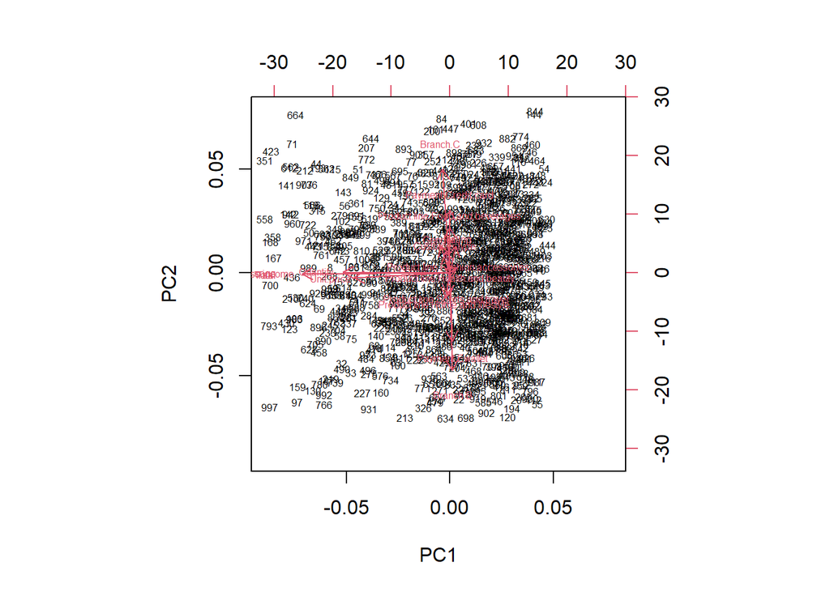

```r
df.pr %>% biplot(cex = .5)
```

# Implementing the Solution

### Feature Ranking

```r
#suppressWarnings(suppressMessages(if(!require(FSelector, quietly=TRUE)) #install.packages("FSelector")))
library(FSelector)


#Ranking variables

Scores <- linear.correlation(df.final)
Scores %>% arrange(desc(Scores$attr_importance))
```

```
##                                  attr_importance
## Branch.C                            0.4925304621
## Rating                              0.0634622646
## Product.line.Food.and.beverages     0.0435098209
## Product.line.Sports.and.travel      0.0393096155
## Payment.Credit.card                 0.0263675441
## Gender                              0.0183976367
## Product.line.Home.and.lifestyle     0.0180716450
## Product.line.Fashion.accessories    0.0161210539
## Product.line.Health.and.beauty      0.0149993437
## cogs                                0.0088760523
## Total                               0.0088760523
## Tax                                 0.0088760523
## gross.income                        0.0088760523
## Payment.Ewallet                     0.0068791258
## Quantity                            0.0067730317
## Customer.type                       0.0056568911
## Unit.price                          0.0003421693
```

The list of important features in descending order is as shown above.

The table below shows the top 5 features.

```r
Subset <- cutoff.k(Scores, 5)
as.data.frame(Subset)
```

```
##                            Subset
## 1                        Branch.C
## 2                          Rating
## 3 Product.line.Food.and.beverages
## 4  Product.line.Sports.and.travel
## 5             Payment.Credit.card
```

As you can see our top five performing features are: >1. Branch.C  
2. Rating  
3. Product.line.Food.and.beverages  
4. Product.line.Sports.and.travel  
5. Payment.Credit.card

# Follow up Questions

1. Did we have the right data? **Yes we did**
2. Did we have the right question? **Yes we did**
3. Do we need to do anything else to answer the question? **No**

# Conclusion and Recommendation

If we were to use five features to build our model, we would use the above.